# Example Random Number Generators

```r
library(ggplot2)
```

##### The following functions will generate 30 numbers that are drawn out of a random normal distribution. Both are drawn from a similar distribution with the same parameters $\mu=10$ and $\sigma=4$. However, as number are drawn randomly out of a infinite amount of numbers, they will always differ as you can see in the plots that follow:

```r
rnn <- rnorm(mean = 10, sd = 4, n = 30)
rnn2 <- rnorm(mean = 10, sd = 4, n = 30)
```

##### Make dataframe:

```r
df <- data.frame(rnn, rnn2)
```

##### Plots:

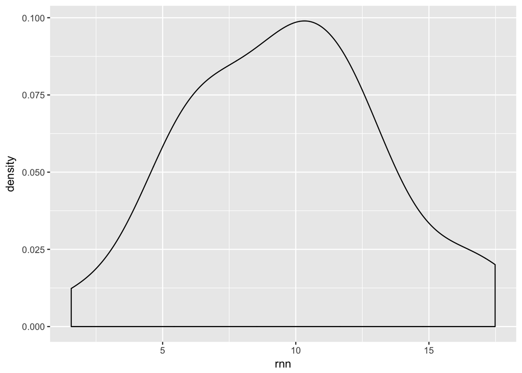

```r
plot_rnn <- ggplot(df, aes(x=rnn)) +
  geom_density()

plot_rnn2 <- ggplot(df, aes(x=rnn2)) +
  geom_density()
plot_rnn
```

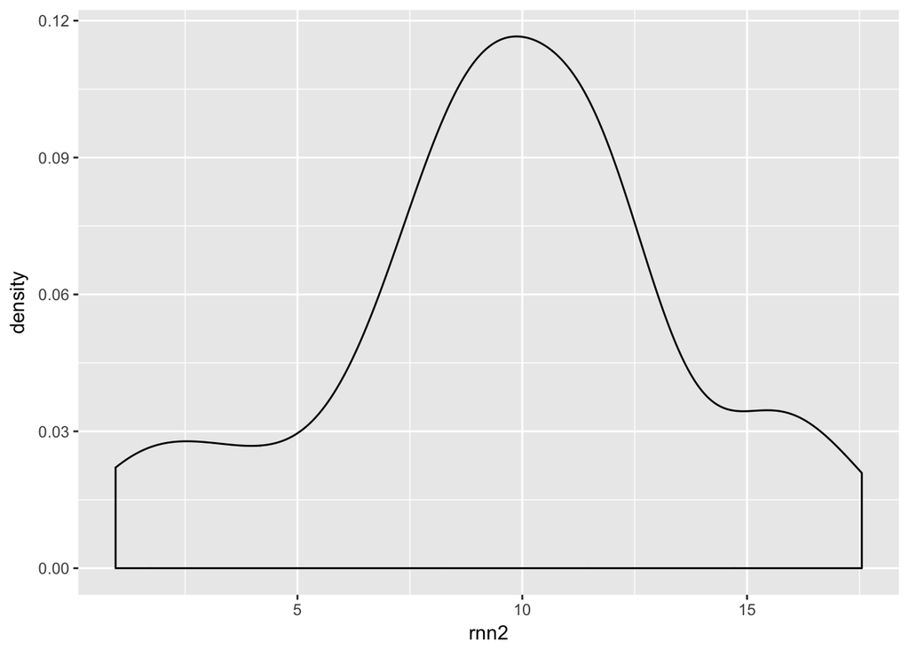

```r
plot_rnn2
```

##### Just like if we would draw samples out of a population, the more samples we draw, the more likely that we get closer to the real distributions:

```r
rnn <- rnorm(mean = 10, sd = 4, n = 10000)
rnn2 <- rnorm(mean = 10, sd = 4, n = 10000)
```

##### Make dataframe:

```r
df <- data.frame(rnn, rnn2)
```

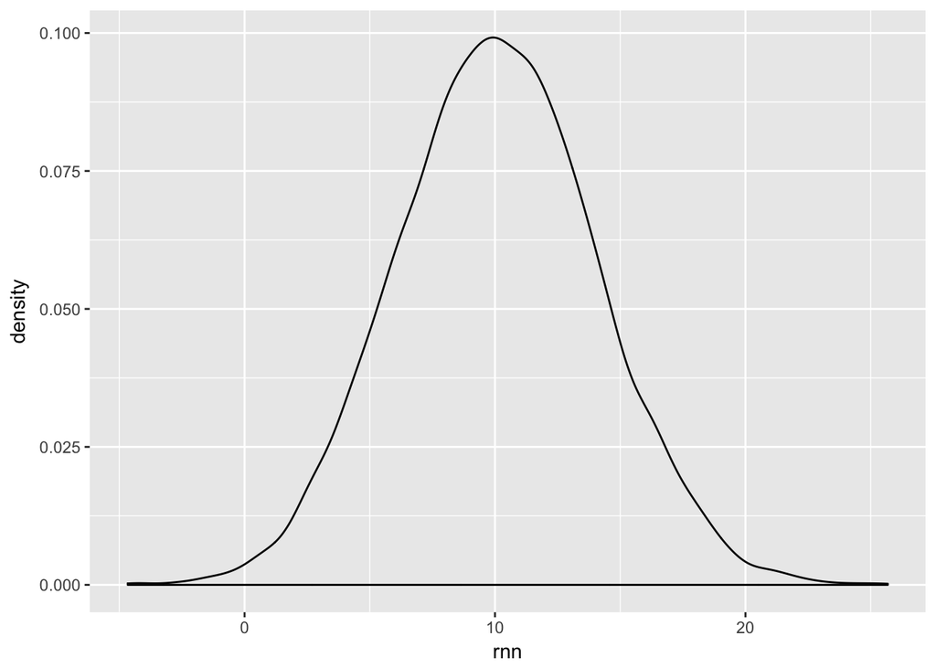

```r
plot_rnn <- ggplot(df, aes(x=rnn)) +
  geom_density()

plot_rnn2 <- ggplot(df, aes(x=rnn2)) +
  geom_density()
plot_rnn
```

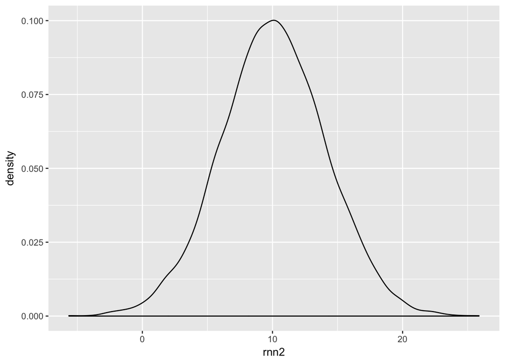

```r
plot_rnn2
```

##### Now, if you use set.seed(), you can control and get the same number because the random number generator is set to the same seed. So, even though we only draw 30, the distributions are exactly the same:

```r
set.seed(50)
rnn <- rnorm(mean = 10, sd = 4, n = 30)
set.seed(50)
rnn2 <- rnorm(mean = 10, sd = 4, n = 30)
```

##### Make dataframe:

```r
df <- data.frame(rnn, rnn2)
```

##### Plots:

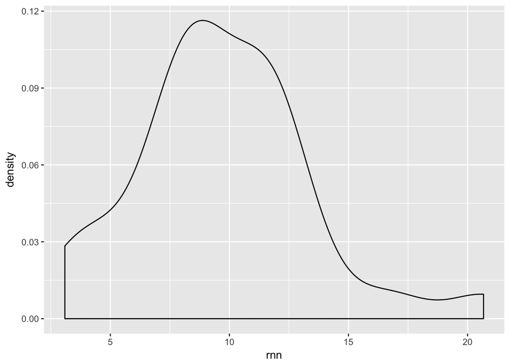

```r
plot_rnn <- ggplot(df, aes(x=rnn)) +
  geom_density()

plot_rnn2 <- ggplot(df, aes(x=rnn2)) +
  geom_density()
plot_rnn
```

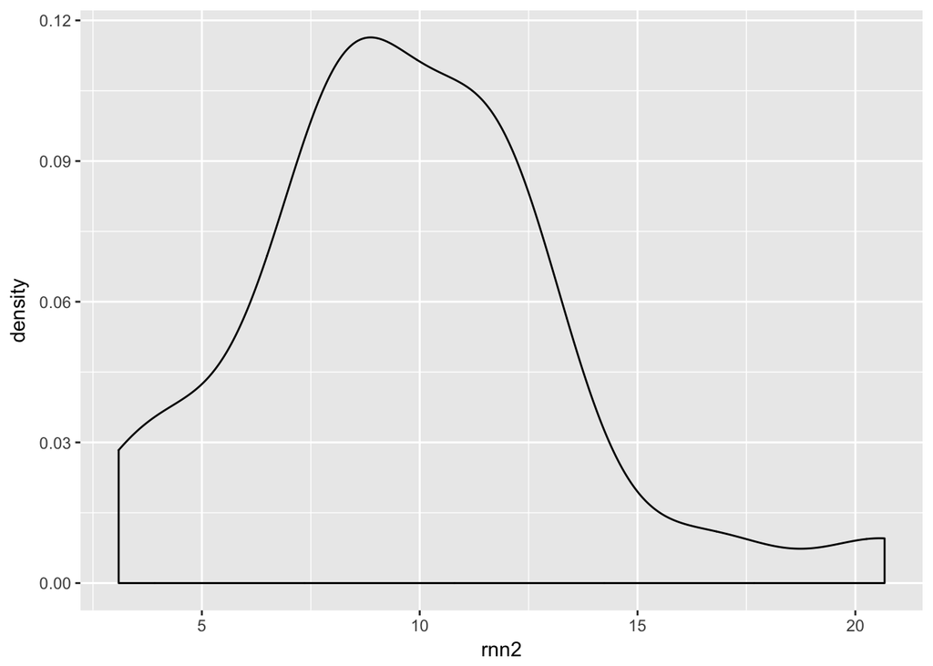

```r
plot_rnn2
```

##### Finally, there are different random number generators to simulate different distributions. runif simulates a uniform distribution where every number has the same likelihood. For rnorm, of course values around the mean have greated likelihood to be drawn. You can also simulate a binomial distribution, poisson, exponential etc.

```r
unif <- runif(0,30, n= 100)
binom <- rbinom(100,1,0.5)
unif
```

```
##   [1] 17.3663331 19.6755441  5.9180222 17.5669386  3.8743032  1.1505309
##   [7] 21.7448824  1.8450446  4.0958674 28.3244589 15.2285387 29.8618972
##  [13] 19.8410340  2.2311928 29.0127620  4.4477915 19.7309170 28.6923188
##  [19] 19.5876643 28.7033579 16.3085823  0.5167584 10.1894964 14.0878904
##  [25] 16.3352217  0.5756088  0.0573610 20.4225513 16.1394398 19.3711093
##  [31] 20.7427110 20.6564262 24.8635295 22.8032495  1.4585486  8.8283023
##  [37]  2.0766229 24.2124991  9.3547257 20.0589378 15.1765721 28.9441253
##  [43] 18.9654540  0.2412013  0.7396424 25.8884146  0.3044852 18.4395310
##  [49] 25.2098689 10.5917903 26.3515513  2.1709763  5.8041426  3.3972569
##  [55]  2.4636248  9.6683435  2.7397946 23.6954217 13.3436516 29.5909479
##  [61] 18.7394999  0.5631572 16.1152711 16.6372363 15.4524865 13.8087149
##  [67]  7.8913980  1.2817528  2.2812160  7.7063244 10.7997398  5.6988156
##  [73] 24.2294217 13.7399420  2.9710439  8.2487931 16.2938256  9.7271309
##  [79]  5.2821117 14.3104560 16.2428590  4.8188769  7.8171668  5.2297675
##  [85]  1.4423659 12.4646062 21.2359962 18.7605669 15.9033816 12.2274913
##  [91]  6.5035673  6.7283805 11.8765070 29.3364164 24.8408304 13.8506108
##  [97]  4.4525807  8.7931953 19.8027220  1.1599381
```

```r
binom
```

```
##   [1] 0 0 1 1 1 1 0 0 1 0 1 1 0 0 0 0 0 1 0 1 1 0 1 1 1 1 1 0 0 0 1 0 0 1 1
##  [36] 0 0 1 1 0 0 1 1 0 1 0 1 0 1 0 1 1 0 0 1 0 0 1 0 1 1 0 0 0 0 0 1 0 0 0
##  [71] 0 0 0 0 1 1 0 1 0 0 0 0 1 0 0 1 0 1 0 0 1 1 0 1 1 1 0 1 0 1
```